# DatePalm - Dates NFT

The DatePalm Dates NFT collection consists of 10 different date fruit types. This project is part of the DatePalm DAO (Decentralised Autonomous Organisation) which is a charity organisation aimed to help those in need around the world.

### Design requirements

1. We require 10 different illustations of 10 different types of dates. These illustrations should be created as vectors and all file formats should be delivered. Initial drafts will be required to verify the design spec.
1. Logo design for organisation.

[figure not shown]

- 10 illustrations of dates.

#### Layers

1. skin/type
   - This is the shape and skin of the date.
   - Some of these are quite similar so some detail for differnece should be taken into account.
1. colour
   - Each date type will have it's own colour or shade of colour.
- Each date should be drawn in the same angle.

## 10 Dates

## 1. Ajwa

[figure not shown]

Ajwa dates are soft dry, medium-size date variety that is about 3 centimeters in length. They have glossy black-brown skin and pulp. The pulp surrounds a central elongated seed that is often removed. Ajwa dates have a meaty, chewy texture and a sweet flavor with hints of caramel, honey, and cinnamon.

Ajwa dates are the fruit of date palms botanically classified as Phoenix dactylifera. They are grown and cultivated in Medina, Saudi Arabi and considered one of the most expensive dates in the world.

## 2. Medjool

[figure not shown]

Medjool dates are plump and cylindrical in shape, measuring about 2 to 3 inches in length and an inch in diameter. The skin is glossy and tender with a maple-brown hue, and the meaty amber-colored pulp offers a chewy texture and candy-like sweetness with hints of caramel, honey, and cinnamon. Encased in the meaty pulp is a single elongated pit, which is removed before consumption. Don’t be deterred if there is a bit of white film on the fruit’s surface, as that's just natural sugars crystalizing and rising to the top of the skin. Date fruits grow in clusters on the date palm tree, and more than 1,000 dates may appear on a single bunch. Date palms are known to live as long as 150 years, though their fruit production declines with older age. The Medjool date is typically left to ripen on the tree in order to maximize its natural sugar development.

## 3. Mabroom

[figure not shown]

Mabroom dates are deliciously sweet and sticky, with light red-bronze skin and a lingering toffee-like taste on the palate. They have a smooth and pleasant flavor but are much firmer than other date varieties. Some may even find them quite hard to chew

## 4. Deglet Noor

[figure not shown]

The Deglet Noor is a medium sized date with a narrow elongated oval shape. They range in color from straw yellow to amber toned with a slightly translucent exterior. Their texture is considered semi-dry and often described as having a slight snappy crunch. Compared to the Medjool, they have less sugar but offer a complex sweetness with a nutty finish likened to browned butter and cashew.

## 5. Khudri

[figure not shown]

Khudri dates are a uniform dark brown color, not too wrinkly (dates can range from smooth to as wrinkly as a prune depending on the variety). The skin of these dates flake a little.

## 6. Sagai

[figure not shown]

Living well means eating well, but that doesn’t mean your food should look or taste bland! Sagai Dates are famous for their two-toned color and texture. At their base, they are golden and slightly dry, while the rest of their body is brown and soft. From beginning to end, they’re simply delicious.

They have a mild sweetness but fierce health benefits. Jam-packed with fiber, potassium, copper and more, this wholesome treat is designed to help restore your bone, brain, heart and digestive health.

## 7. Sukkari

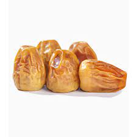

Dates Sukkari Rutab is distinguished by its large grain and golden outer crust. It was called sugary due to its sweetness and taste.Dates Sukkari Rutab are the best-tasting dates among most types of dates, if not all. It is also considered the best-selling date.

One of the most important characteristics of Dates Sukkari Rutab is that it has a caramel-like taste.

## 8. Safawi

[figure not shown]

Safawi dates are a soft, moist variety of dates that mainly grow in Saudi Arabia in the Al-Madina region. Safawi dates are characteristically identified by their particular deep black colour and consist of medium and long fruits. The Safawi date resembles the Ajwa date concerning the refined structure and taste.

## 9. Zahidi

[figure not shown]

Zahidi dates are medium sized and distinctively oval in shape. They have pale brown skin and a thick, golden inner flesh that surrounds a single seed. When compared to the Medjool which is often regarded as the standard in the date world, they have a considerably lower sugar content. Chewy, and semi-dry in texture, the Zahidi date has a mildly sweet, nutty and buttery flavor with a subtle tang reminiscent of dried apricots.

## 10. Mazafati

[figure not shown]

It is a dark, soft, fleshy and sweet date of medium size, about 2.5–4.5 cm (1–2 in) with a relatively high moisture content of between 32-35%, varying with the time of harvest and the location of the grove.

# DatePalm Logo

The logo should consist of the name DatePalm and perhaps an illustration of a date palm tree. We will require unlimited revisions on the logo to ensure we have what we are looking for.

## Logo examples

[figure not shown]

# Deadline & Budget

### Deadline

We don't have an exact deadline for these requirements as we understand that there will be changes, improvements along the way. However, we would like this to be completed as soon as possible.

- We would like drafts to be delievered within a week of project starting.

### Budget

The budget will be discussed directly once you have read this document. This will be paid after the project has launched and NFT sales have been completed. This can be payable by bank transfer, cash or via cryptocurrency.

**Note:** As this is indeed a **charity** project, we have chosen to make payment once we have launched the project.

**We will require a long term designer on our team. Therefore, discussions about full/part-time contracts can be discussed as the project evovles.**